# Machine learning project

koem32

September 12, 2014

# Abstract

This research project aims to predict the type of activity performed by 6 subjects using data measurements from accelerometers on the belt, forearm, arm, and dumbell. We used a training and testing set to perform this prediction and applied a random forest model to generate a predictor with an estimated out of sample error rate of less than 0.5%. As a result we believe this to be a very accurate predictor. Applying this predictor to our testing set resulted in 100% accuracy

The data set is available from the website here: http://groupware.les.inf.puc-rio.br/har.

# Data Preprocessing

Create a file in the working directory called “machineLearningProjectKoem32” if it does not already exist and download the files into it.

```r
if (!file.exists("machineLearningProjectKoem32")) {dir.create("machineLearningProjectKoem32")}
fileUrl <- "https://d396qusza40orc.cloudfront.net/predmachlearn/pml-training.csv"
download.file(fileUrl, destfile = "./machineLearningProjectKoem32/pml-training.csv", method = "curl")
fileUrl2 <- "https://d396qusza40orc.cloudfront.net/predmachlearn/pml-testing.csv"
download.file(fileUrl2, destfile = "./machineLearningProjectKoem32/pml-testing.csv", method = "curl")

training<-read.csv(file="machineLearningProjectKoem32/pml-training.csv",head=TRUE,sep=",")
testing<-read.csv(file="machineLearningProjectKoem32/pml-testing.csv",head=TRUE,sep=",")
```

Next we get rid of all column which are full of NAs in the training set and similarly remove these same columns from testing set. We also remove the first 6 columns (x column is just a counter and the other time variables are uniterpretable)

```r
training3<-training2[,apply(training2,2,function(xx) !any(is.na(xx)))]
testing3<-testing2[,apply(training2,2,function(xx) !any(is.na(xx)))]
training4<-training3[,-(1:6)]
testing4<-testing3[,-(1:6)]
```

Next we check there are no NAs or blank fields in the training set

```r
sum(training4=="")
```

```
## [1] 0
```

```r
sum(is.na(training4))
```

```
## [1] 0
```

Looks ok so we are good to go.

# Applying a prediction model

In order to estimate the out of sample error rate we create a new training and cross validation set from the training set

```r
set.seed(234)
inTrain <- createDataPartition(y=training4$classe, p=0.75, list=FALSE)
newTraining<-training4[inTrain,]
newTesting<-training4[-inTrain,]
```

Since we are trying to find a classification prediction, we are going to try applying random forests We apply the random forest algorithm to new training set and predict on the cross validation set to get an estimate of out of sample error

```r
library(randomForest)
set.seed(354)
modFit<-randomForest(newTraining$classe~.,data=newTraining,ntree=300,keep.forest=TRUE)
pred<-predict(modFit, newTesting)
confusionMatrix(pred,newTesting$classe)
```

```
## Confusion Matrix and Statistics
##
##           Reference
## Prediction    A    B    C    D    E
##          A 1395    5    0    0    0
##          B    0  942    6    0    0
##          C    0    2  848    9    0
##          D    0    0    1  795    1
##          E    0    0    0    0  900
##
## Overall Statistics
##
##                Accuracy : 0.995
##                  95% CI : (0.993, 0.997)
##     No Information Rate : 0.284
##     P-Value [Acc > NIR] : <2e-16
##
##                   Kappa : 0.994
##  Mcnemar's Test P-Value : NA
##
## Statistics by Class:
##
##                      Class: A Class: B Class: C Class: D Class: E
## Sensitivity             1.000    0.993    0.992    0.989    0.999
## Specificity             0.999    0.998    0.997    1.000    1.000
## Pos Pred Value          0.996    0.994    0.987    0.997    1.000
## Neg Pred Value          1.000    0.998    0.998    0.998    1.000
## Prevalence              0.284    0.194    0.174    0.164    0.184
## Detection Rate          0.284    0.192    0.173    0.162    0.184
## Detection Prevalence    0.285    0.193    0.175    0.163    0.184
## Balanced Accuracy       0.999    0.996    0.995    0.994    0.999
```

Hence the estimated out of sample error rate is estimated at 1-0.9951=0.5%

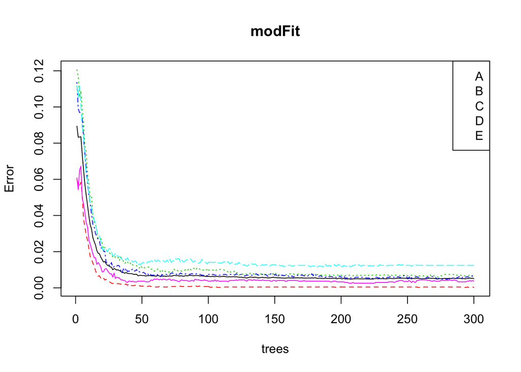

```r
plot(modFit,type="l")
legend("topright", legend=unique(newTraining$classe) )
```

Now let’s apply this model to the original testing set

```r
answers<-predict(modFit, testing4[,-53])
answers
```

```
##  1  2  3  4  5  6  7  8  9 10 11 12 13 14 15 16 17 18 19 20
##  B  A  B  A  A  E  D  B  A  A  B  C  B  A  E  E  A  B  B  B
## Levels: A B C D E
```

Finally I can download the answers into txt files in a folder names machineLearningAnswers into the working directory so as to submit them for this project

```r
pml_write_files = function(x){
  n = length(x)
  for(i in 1:n){
    filename = paste0("problem_id_",i,".txt")
    write.table(x[i],file=filename,quote=FALSE,row.names=FALSE,col.names=FALSE)
  }
}
if (!file.exists("machineLearningAnswers")) {dir.create("machineLearningAnswers")}
setwd("./machineLearningAnswers")
pml_write_files(answers)
```